# APIX multo

Equipe 9

2024-02-24

# Apixaban (anti-Xa) :

Nous diposons d’échantillons d’étalonnage à diverses dates, pour divers automates et divers réactifs. Nous allons étudier l’influence de ces différents facteurs sur les droites d’étalonages.

Commençons par charger afficher pour chaque échantillon d’étalonnage le nuage de point et la droite d’étalonnage :

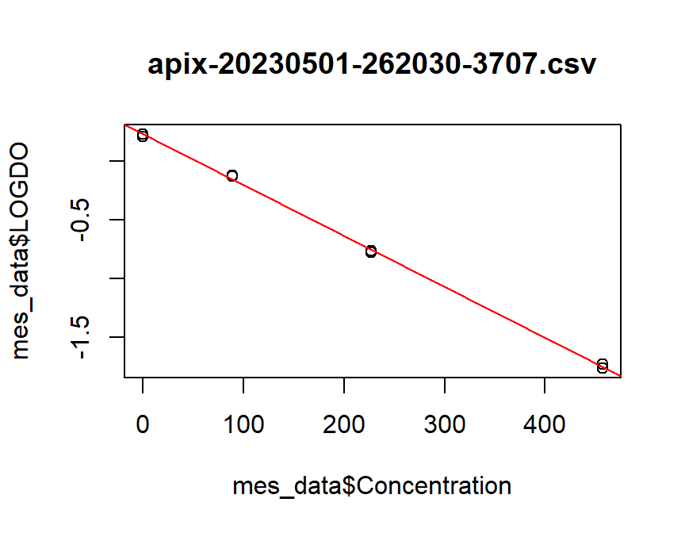

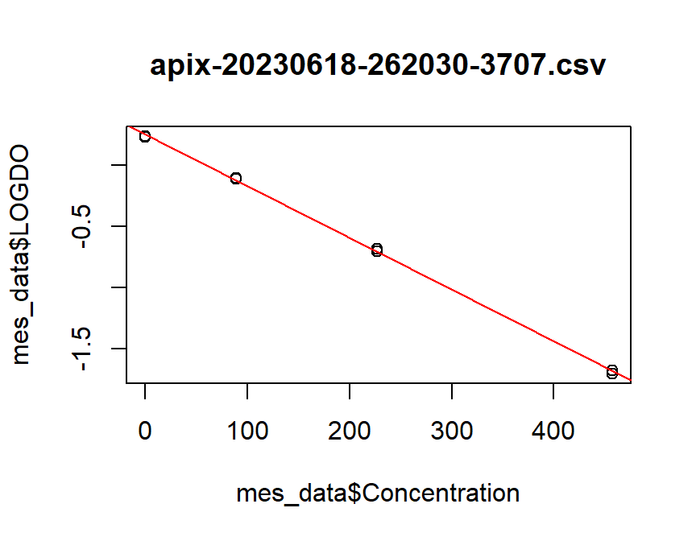

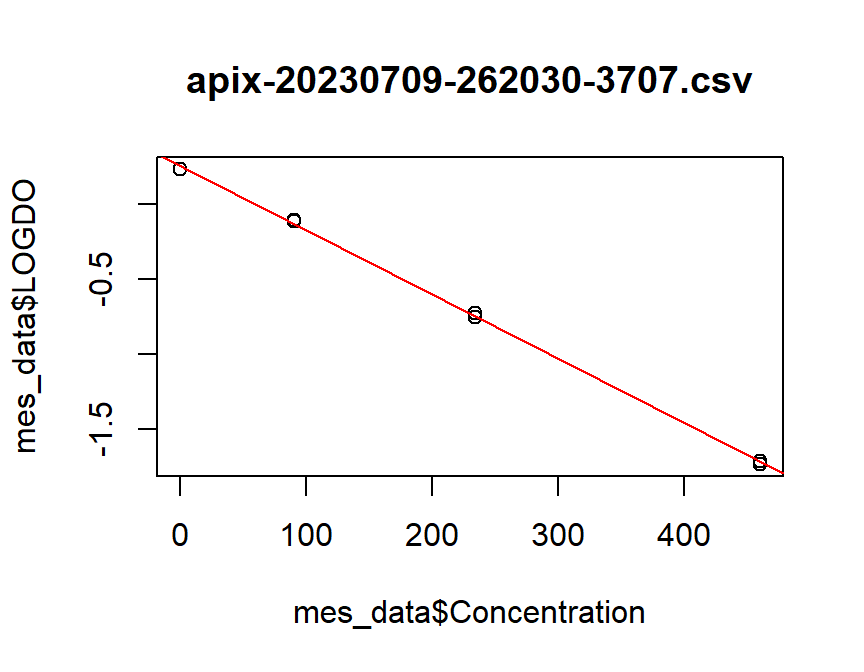

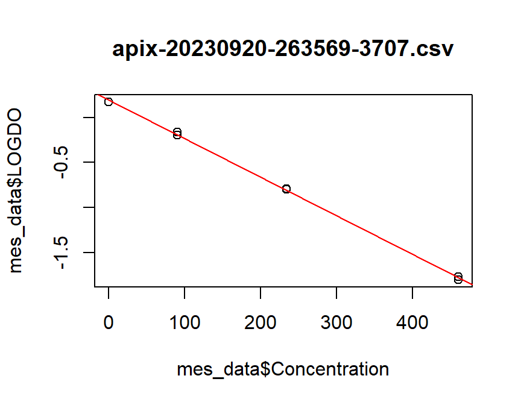

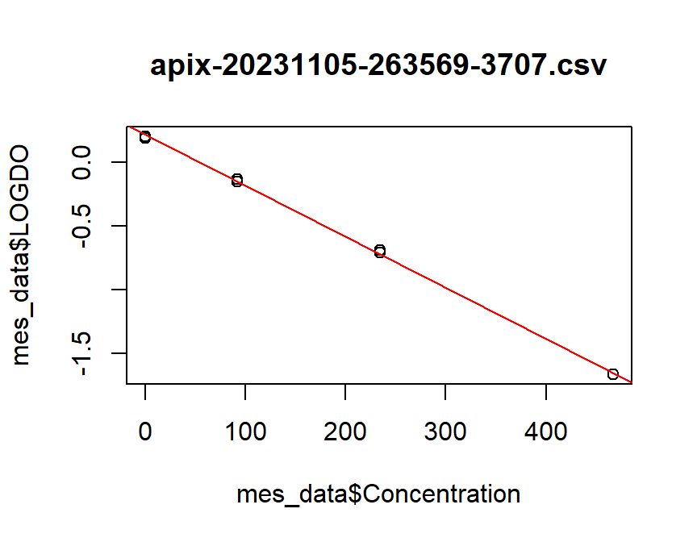

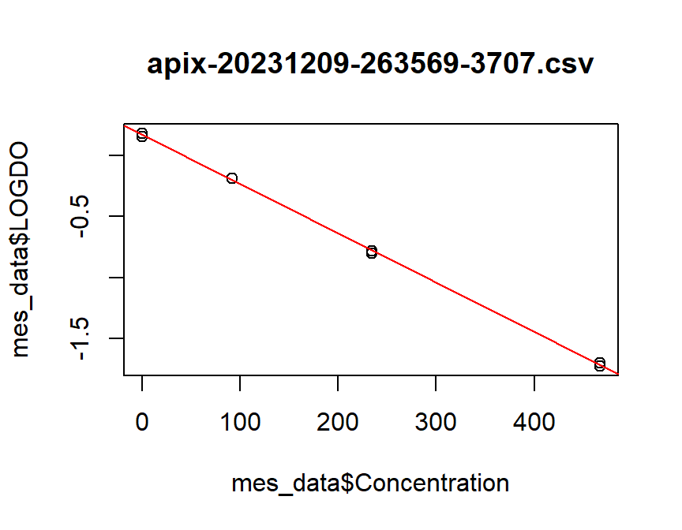

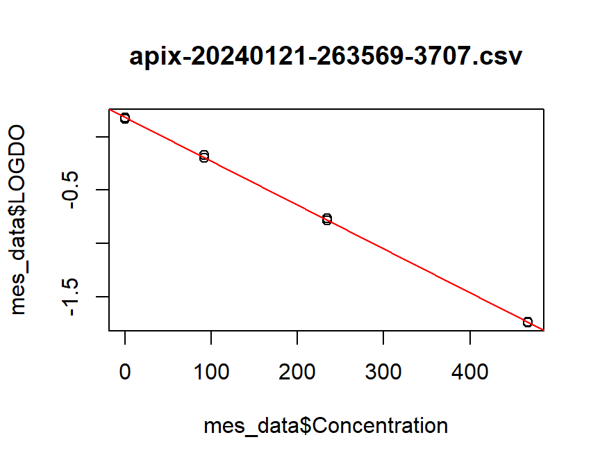

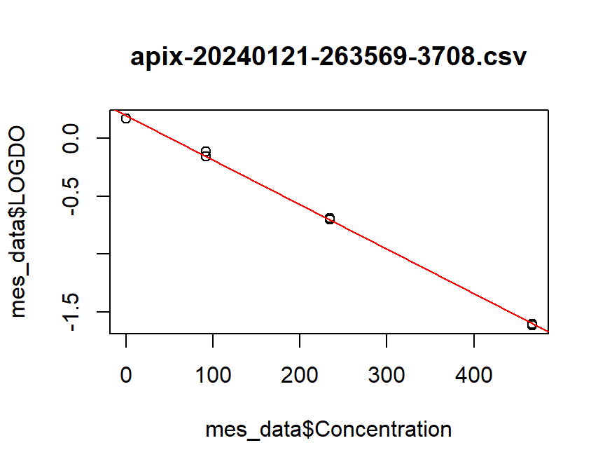

On constate que sur chaque échantillon les points semblent alignés et qu’aucun point ne s’écarte significativement de la droite de régression linéaire.

Voyons l’aspect des résidus de régression pour nos différents échantillons :

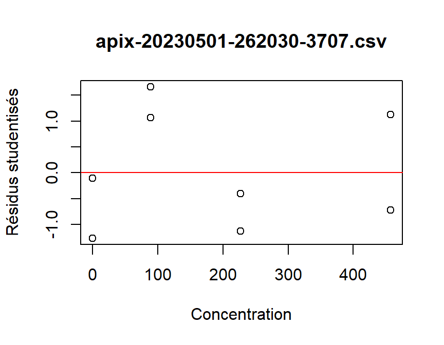

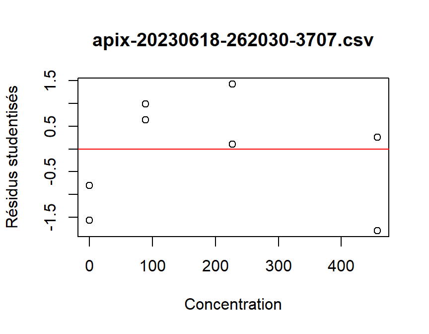

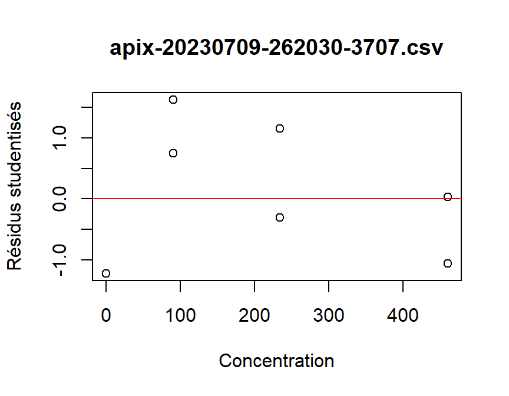

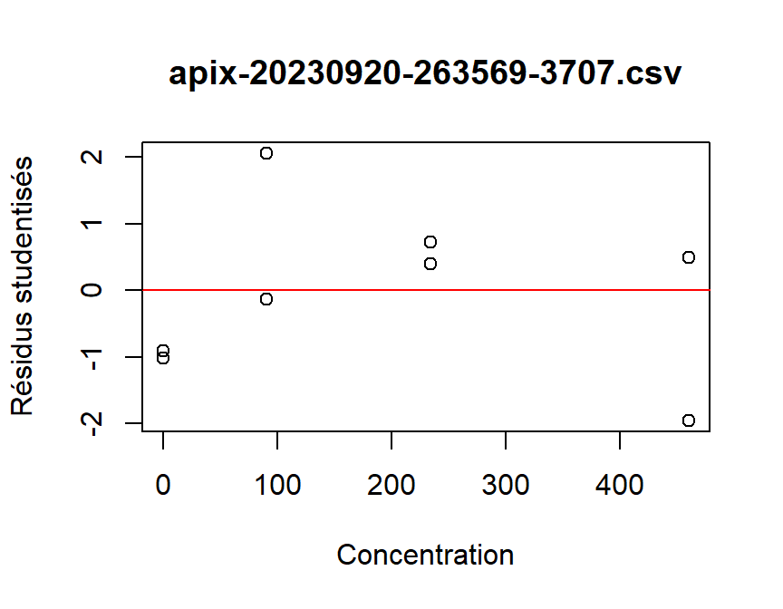

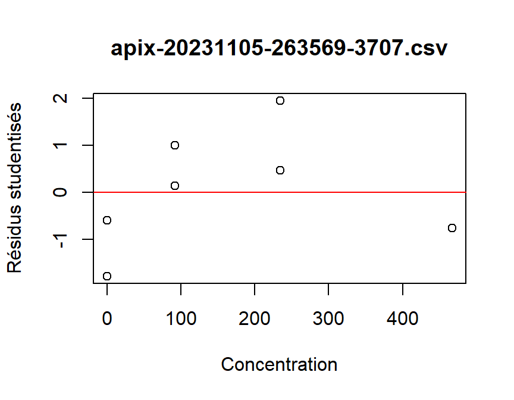

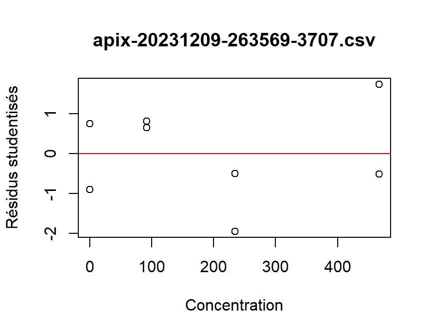

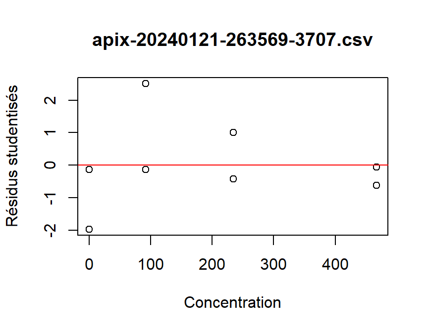

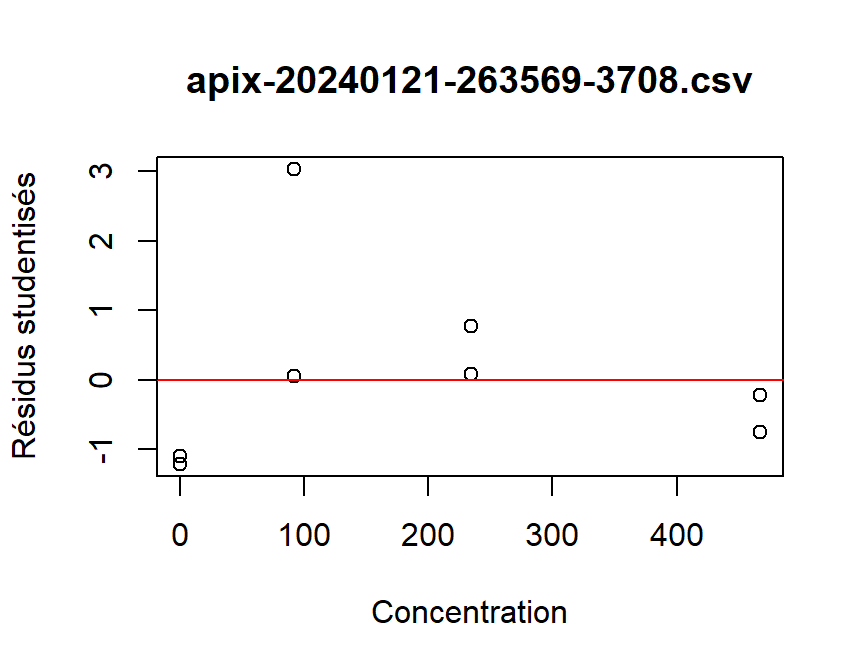

Ici, rien ne nous incite à remettre en cause l’hypothèse d’homoscédasticité.

Affichons sur un même graphique l’ensemble de nos échantillons :

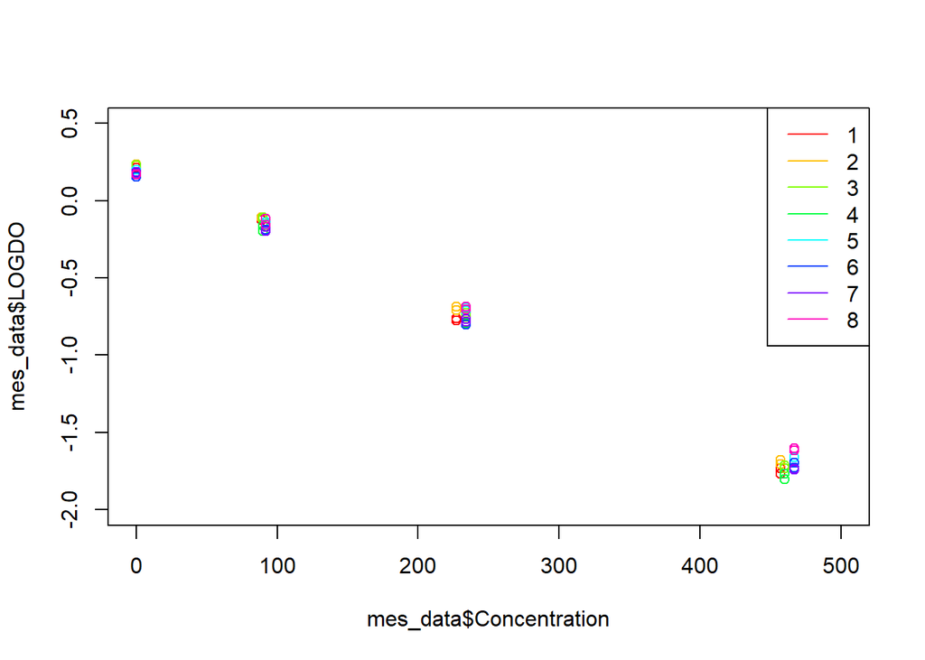

```r
couleurs <- rainbow(length(files))

i = 1
for (file in files) {
  mes_data = read.csv2(file, sep = ";")
  mes_data$LOGDO <- log(mes_data$DO)
  if(i==1){
    plot(mes_data$Concentration, mes_data$LOGDO, col = couleurs[i], xlim=c(0,500), ylim = c(-2, 0.5))
  }
  else{
    points(mes_data$Concentration, mes_data$LOGDO, col = couleurs[i])
  }
  i <- i+1
}
legend("topright", legend = c(1:length(files)), col = couleurs[1:length(files)], lty = 1)
```

Tout comment lors de l’étude de l’argabotran, on constate une augmentation de la dispersion avec l’augmentation des concentrations. Sur ce graphique, il est cependant difficile de de voir si cette augmentation apparente de la dispersion se retrouve sur chaque échantillon d’étalonnage ou provient d’écarts de tendances des différentes échantillons d’étalonnage.

Nous allons maintenant construire un tableau contenant les coefficients des différentes régressions linéaires ainsi que leurs intervalles de confiances à 90% et la variance résiduelle de la régression. Ce tableau contiendra aussi les limites de blancs calculées à partir des courbes d’étalonnage pour un niveau de confiance de 95% et la limite de quantificaton relative pour une précision de 15% et un niveau de confiance de 90%.

```r
col_names <- c("produit", "date", "réactif", "automate", "b0", "b0-","b0+", "sigmab0", "b1","b1-","b1+", "sigmab1","sigma", "LOB", "LOQ")
tab_out <- data.frame(matrix(ncol = length(col_names), nrow = 0))
for (file in files) {
  mes_data = read.csv2(file, sep = ";")
  mes_data$LOGDO <- log(mes_data$DO)
  modele <- lm(formula = mes_data$LOGDO ~ mes_data$Concentration)
  summary_modele <- summary(modele)

  tokens <- unlist(strsplit(gsub("\\.csv","", basename(file)), "-"))
  level <- 0.95
  b0 <- modele$coefficients[1]
  b1 <- modele$coefficients[2]
  sigma_b0 <- summary_modele$coefficients[1,2]
  sigma_b1 <- summary_modele$coefficients[2,2]
  n <- nrow(mes_data)
  b0m <- b0 - qt(level, n-2) * sigma_b0
  b0p <- b0 + qt(level, n-2) * sigma_b0
  b1m <- b1 - qt(level, n-2) * sigma_b1
  b1p <- b1 + qt(level, n-2) * sigma_b1
  limites <- calcul_limites(modele, level)

  ligne <- c(b0, b0m, b0p, sigma_b0, b1, b1m, b1p, sigma_b1, sigma(modele), limites$LOB, limites$LOQ)

  tab_out <-rbind(tab_out, c(tokens, round(ligne,5)))

}
colnames(tab_out) <- col_names

print(tab_out)
```

```
##   produit     date réactif automate      b0     b0-     b0+ sigmab0       b1
## 1    apix 20230501  262030     3707 0.23596 0.21082 0.26111 0.01294 -0.00435
## 2    apix 20230618  262030     3707 0.24962 0.22935 0.26989 0.01043 -0.00422
## 3    apix 20230709  262030     3707 0.25194   0.231 0.27288 0.01078 -0.00428
## 4    apix 20230920  263569     3707 0.19022 0.16765  0.2128 0.01162 -0.00427
## 5    apix 20231105  263569     3707 0.21182 0.19154 0.23209 0.01043 -0.00398
## 6    apix 20231209  263569     3707 0.16982 0.15152 0.18811 0.00942 -0.00404
## 7    apix 20240121  263569     3707 0.18548 0.17233 0.19863 0.00677 -0.00412
## 8    apix 20240121  263569     3708 0.19292 0.16772 0.21811 0.01297 -0.00384
##        b1-      b1+ sigmab1   sigma      LOB      LOQ
## 1 -0.00445 -0.00425   5e-05 0.02436 12.32197 41.27464
## 2  -0.0043 -0.00415   4e-05 0.01964 10.22975 34.39224
## 3 -0.00436  -0.0042   4e-05 0.02022 10.40971 34.98722
## 4 -0.00436 -0.00419   4e-05  0.0218 11.23585 37.70873
## 5 -0.00406 -0.00391   4e-05  0.0196 10.82761  36.3755
## 6 -0.00411 -0.00397   4e-05 0.01769  9.62892 32.41709
## 7 -0.00417 -0.00407   3e-05 0.01272  6.80166 23.01809
## 8 -0.00393 -0.00374   5e-05 0.02436 13.96833 46.67803
```

```r
write.csv2(tab_out, file = "apix_output.csv", sep = ";")
```

On constate une forte variabilités aussi bien des limites blancs que des limites de quantifications, qui peuvent passer du simple au double d’une courbe d’étalonnage à l’autre ce qui s’explique en grande partie pas les écarts de variance résiduelle.

Concernant les coefficients de la régression linéaire, on constate que les intervalles de confiance associés aux $\hat{\beta_0}$ des différents courbes d’étalannage sont parfois disjoint. De même, les intervalles de confiance associées aux $\hat{\beta_0}$ des différentes courbes sont parfois disjoints ce qui laisse envisagé que les différences de pente entre les droites d’étalonnage ne soit pas uniquement le fruit du hasard.

Les régions de confiances associées aux couples $(\hat{\beta_0}, \hat{\beta_1})$ représenté sur le graphique suivant permettent de visualiser ces écarts.

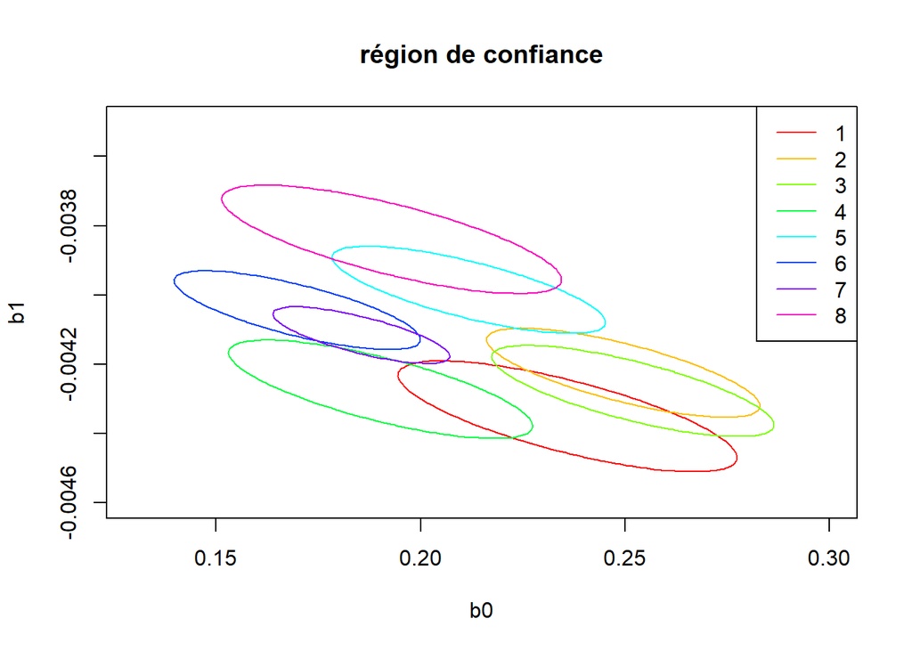

```r
xlim = c(0.13, 0.30)
ylim = c( -0.0046, -0.0035)
plot(NULL, xlim = xlim, ylim = ylim , xlab = "b0", ylab = "b1", main = "région de confiance")

couleurs <- rainbow(length(files))

i = 1
for (file in files) {
  mes_data = read.csv2(file, sep = ";")
  mes_data$LOGDO <- log(mes_data$DO)
  modele <- lm(formula = mes_data$LOGDO ~ mes_data$Concentration)
  dessine_region_conf(modele, 0.95, xlim, ylim, couleurs[i])
  i <- i+1
}
legend("topright", legend = c(1:length(files)), col = couleurs[1:length(files)], lty = 1)
```

## Dépendance à l’automate

Nous disposons de deux echantillons d’étalonnage réalisés le même jour avec le même réactif sur deux automates différents. Comparons leurs régions de confiances :

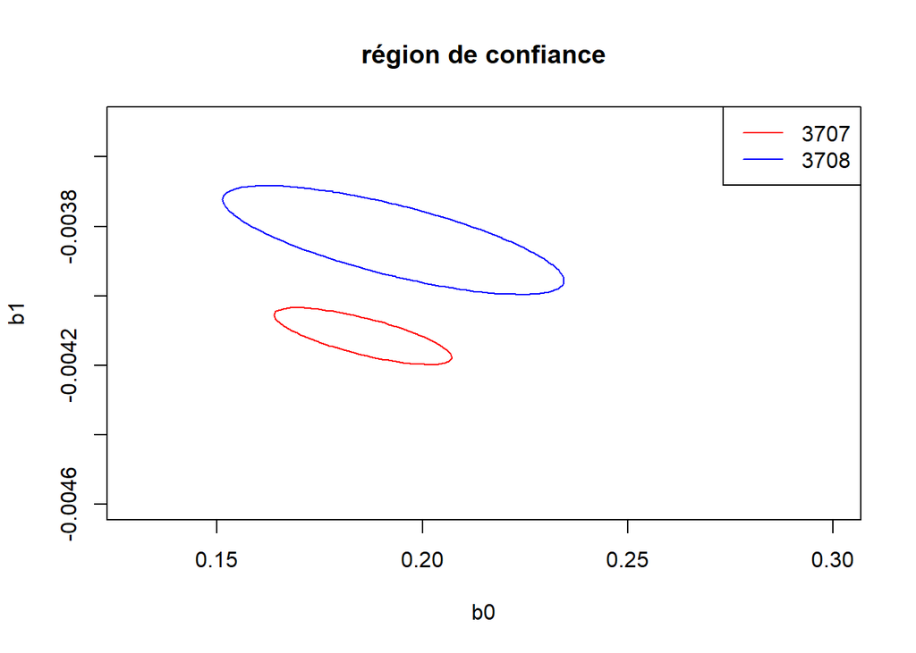

```r
xlim = c(0.13, 0.30)
ylim = c( -0.0046, -0.0035)
plot(NULL, xlim = xlim, ylim = ylim , xlab = "b0", ylab = "b1", main = "région de confiance")

couleurs <- c("red","blue")

i = 1
for (file in files) {
  if(i<7){
    i = i+1
    next
  }
  mes_data = read.csv2(file, sep = ";")
  mes_data$LOGDO <- log(mes_data$DO)
  modele <- lm(formula = mes_data$LOGDO ~ mes_data$Concentration)
  dessine_region_conf(modele, 0.95, xlim, ylim, couleurs[i-6])
  i <- i+1
}
legend("topright", legend = tab_out$automate[7:8], col = couleurs, lty = 1)
```

Nous constatons que les régions de confiance sont alignées verticalement, ce qui ne laisse pas présager de différences de $\hat{\beta_0}$. En revanche les deux régions de confiance sont disjoints et sont situés l’un au dessus de l’autre ce qui indique que l’automate pourrait avoir une influence sur la pente de la courbe d’étalonnage.

## Dépendance au réactif

Deux lot de réactif ont été utilis lors de la confection de l’échantillon de courbe d’étalonnage. Nous allons Comparer en terme de réactif les échantillons réalisés sur l’automate 3707 :

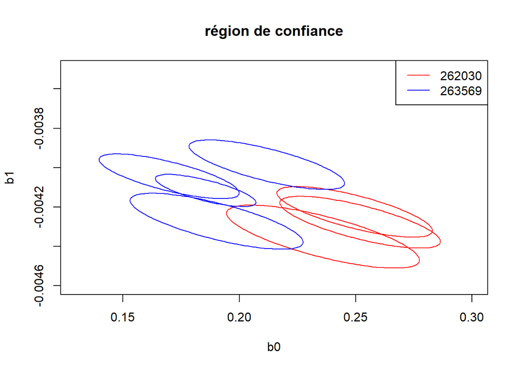

```r
xlim = c(0.13, 0.30)
ylim = c( -0.0046, -0.0035)
plot(NULL, xlim = xlim, ylim = ylim , xlab = "b0", ylab = "b1", main = "région de confiance")

i = 1
couleur <- "red"
for (file in files) {
  mes_data = read.csv2(file, sep = ";")
  mes_data$LOGDO <- log(mes_data$DO)
  modele <- lm(formula = mes_data$LOGDO ~ mes_data$Concentration)
  dessine_region_conf(modele, 0.95, xlim, ylim, couleur)
  i <- i+1
  if(i>3){
    couleur <- "blue"
  }
  if(i>7){
    break
  }
}
legend("topright", legend = c(262030, 263569), col = c("red", "blue"), lty = 1)
```

On remarque un décallage horizontale entre les régions de confiance des courbes d’étalonnage réalisé avec le réactif 262030 et celles réalisés avec le réactif 263569. Le réactif semble avoir une influence sur la valeur de $\hat{\beta_0}$. C’est à dire qu’un changement de réactif pourrait générer un décalage vertical de la courbe d’étalonnage. Il faut toutefois rester prudent sur les interprétations. Nous ne disposons ici que de deux lots de réactifs. Nos observations ne restent valable que sur ces deux observations et ne peuvent en aucun cas être généralisées.

## Dépendance au temps

Pour l’automate 3707, pour chacun des 2 lots de réactifs nous disposons de plusieurs courbes d’étalonnage réalisées à différentes date.

Commençons par nous intéresser aux régions de confiances associées aux courbes d’étalonnage réalisées avec le réactif 262030 :

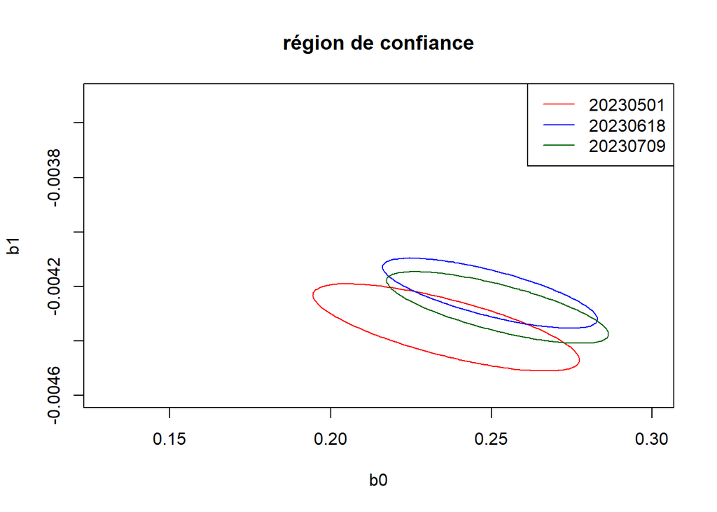

```r
xlim = c(0.13, 0.30)
ylim = c( -0.0046, -0.0035)
plot(NULL, xlim = xlim, ylim = ylim , xlab = "b0", ylab = "b1", main = "région de confiance")

i = 1
couleurs <- c("red","blue","darkgreen")
for (file in files) {
  mes_data = read.csv2(file, sep = ";")
  mes_data$LOGDO <- log(mes_data$DO)
  modele <- lm(formula = mes_data$LOGDO ~ mes_data$Concentration)
  dessine_region_conf(modele, 0.95, xlim, ylim, couleurs[i])
  i <- i+1
  if(i>3){
    break
  }

}
legend("topright", legend = tab_out$date[1:3], col = couleurs[1:3], lty = 1)
```

Il semblerait que les la date de réalisation de la courbe d’étalonnage puisse avoir une influence sur sa pente. Voyons ce qu’il en est des régions de confiances associées aux courbes d’étalonnage réalisées avec le réactif 263569.

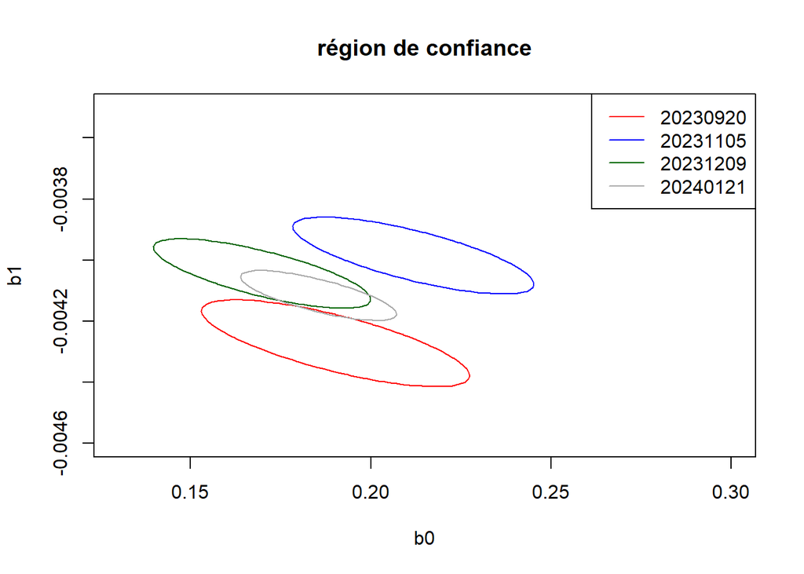

```r
xlim = c(0.13, 0.30)
ylim = c( -0.0046, -0.0035)
plot(NULL, xlim = xlim, ylim = ylim , xlab = "b0", ylab = "b1", main = "région de confiance")

i = 1
couleurs <- c("red","blue","darkgreen", "darkgrey")
for (file in files) {
  if(i<4){
    i <- i+1
    next
  }
  mes_data = read.csv2(file, sep = ";")
  mes_data$LOGDO <- log(mes_data$DO)
  modele <- lm(formula = mes_data$LOGDO ~ mes_data$Concentration)
  dessine_region_conf(modele, 0.95, xlim, ylim, couleurs[i-3])
  i <- i+1
  if(i>7){
    break
  }

}
legend("topright", legend = tab_out$date[4:7], col = couleurs[1:4], lty = 1)
```